# Lecture 8

Working with `data.frame`; Data Visualization

Byeong-Hak Choe

bchoe@geneseo.edu

SUNY Geneseo

February 15, 2024

## Announcement

- Liza Mitchell’s tutoring session tomorrow (February 16, 2024) is cancelled.

## Learning Objectives

- R Basics
- Data Visualization with `ggplot()`

# R Basics

## RStudio Workflow

### Must-know Quarto Shortcuts

### Mac

- **option+command+I**: to create a R chunk
- **command+shift+return**: to run the code in the R chunk
- **command + shift + K**: to render/knit the Quarto file
- **command + shift + C**: to (de-)comment out a line in the Quarto file

### Windows

- **Alt+Ctrl+I** : to create a R chunk
- **Ctrl+Shift+Enter** : to run the code in the R chunk
- **Ctrl + Shift + K**: to knit/render the Quarto file
- **Ctrl + Shift + C**: to (de-)comment out a line in the Quarto file

## RStudio Workflow

### Shortcuts for RStudio and RScript

**Mac**

- **command + shift + N** opens a new RScript.
- **command + return** runs a current line or selected lines.
- **command + shift + C** is the shortcut for # (commenting).
- **option + -** is the shortcut for `<-`.

**Windows**

- **Ctrl + Shift + N** opens a new RS-cript.
- **Ctrl + return** runs a current line or selected lines.
- **Ctrl + Shift + C** is the shortcut for # (commenting).
- **Alt + -** is the shortcut for `<-`.

## Workflow for the Course

- Save your Quarto document for each class.
  - Go to **File** and select **Save as…**/ ( e.g., `danl-200-mynote-lec-08-2024-0215.qmd`)
- Store all your class Quarto documents in a dedicated directory, separate from your website project directory.

## Workflow for Your Personal Website

### File management

- Your website project directory should include files specifically dedicated to your website.
- In your website project directory, avoid having
  - Any file that exceeds 30 MB in size;
  - Quarto documents that you do not use for your website.

## Workflow for Your Personal Website

### Quarto Documents and `_quarto.yml`

- Ensure all Quarto documents are rendered well without any errors.
- After making edits to `_quarto.yml`, save the changes by clicking the floppy disk icon (💾).
- Run `quarto render` in Terminal, whenever you have some changes in `_quarto.yml`.
- Once `quarto render` completes, view the `index.html` in your website working directory to see the updates from a web browser.
- After confirming your local website files are well updated, use the 3-step git commands (`add`-`commit`-`push`) to update your online website.

## RStudio Workflow

### RStudio Project

- Keeping all the files associated with a given project (e.g., input data, Quarto documents, and figures) together in one directory is such a wise and common practice.
- RStudio has built-in support for this via **projects**
- We can create a new project by clicking
  - File > New Project
- We use a RStudio project with Version Control and GitHub for the website project and its management.
  - e.g., `bcdanl.github.io`

## RStudio Workflow

### RStudio Project

- Keeping all the files associated with a given project (e.g., input data, Quarto documents, and figures) together in one directory is such a wise and common practice.
- RStudio has built-in support for this via **projects**
- We can create a new project by clicking
  - File > New Project
- We use a RStudio project with Version Control and GitHub for the website project and its management.
  - e.g., `bcdanl.github.io`

## RStudio Workflow

### RStudio Project

```r
# getting the pathname of the current working directory
getwd()
```

- Check that the “home” of your project is the current working directory.

## RStudio Workflow

### Absolute Pathnames

- An absolute path is a complete path from the root directory to the target file or directory.
- *Example (Mac)*: `/Users/bchoe/Documents/bcdanl.github.io/data/car_data.csv`
- *Example (Windows)*: `C:/Users/bchoe/Documents/bcdanl.github.io/data/car_data.csv`

## RStudio Workflow

### Relative Pathnames

- A relative path is a path relative to **the current working directory**.
- *Example (Mac)*: If the current directory is `/Users/bchoe/Documents/bcdanl.github.io/`, the relative path to `car_data.csv` is `data/car_data.csv`
- *Example (Windows)*: If the current directory is `C:/Users/bchoe/Documents/bcdanl.github.io`, the relative path to `car_data.csv` is `data/car_data.csv`
- For any **RStudio project**, it is recommended to use a **relative path**.

## RStudio Workflow

### Example: Absolute vs. Relative Pathnames

```r
path_abs <- "/Users/bchoe/Documents/websites/bcdanl.github.io/data/car_data.csv"
df_car_a <- read_csv(path_abs)

getwd()    # "/Users/bchoe/Documents/websites/bcdanl.github.io"
path_rel <- "data/car_data.csv"
df_car_r <- read_csv(path_rel)
```

## R Basics

### Working with Data from Files

- We use the `read_csv()` function to read a comma-separated values (CSV) file.
1. Download the CSV file, `car_data.csv` from the Class Files module in our Brightspace.
2. Find the path name for the file, `car_data.csv` from the File Explorer / Finder.
3. Provide the path name for the file, `car_data.csv`, to the `read_csv()` function.

```r
uciCar <- read_csv('HERE WE PROVIDE A PATHNAME FOR car_data.csv')
View(uciCar)
```

- `View()`/`view()` displays the data in a simple spreadsheet-like grid viewer.

## R Basics

### Examining `data.frames`

```r
class(uciCar)
```

```r
dim(uciCar)
nrow(uciCar)
ncol(uciCar)
```

```r
library(skimr)
skim(uciCar)
```

- `dim()` shows how many rows and columns are in the data for `data.frame`.
- `nrow()` and `ncol()` shows the number of rows and columns for `data.frame` respectively.
- `skimr::skim()` provides a more detailed summary.
  - `skimr` is the R package that provides the function `skim()`.

## R Basics

### Reading data.frames from an URL

```r
tvshows <- read_csv(
        'https://bcdanl.github.io/data/tvshows.csv')
```

- We can import the CSV file from the web.

## R Basics

### Tidy `data.frame`: Variables, Observations, and Values

- There are three rules which make a `data.frame` tidy:
  1. Each **variable** must have its own *column*.
  2. Each **observation** must have its own *row*.
  3. Each **value** must have its own *cell*.

## R Basics

### R Variable and Data Types

- Questions 3-5 in [Classwork 5](https://bcdanl.github.io/200/danl-cw/danl-200-cw-05.html)

# Data Visualization with `ggplot()`

## Exploratory Data Analysis

- In data visualization, you’ll turn data into plots.
- In data transformation, you’ll learn the key verbs that allow you to select important variables, filter out key observations, create new variables, and compute summaries.
- In **exploratory data analysis**, you’ll combine summary statistics (`skim()`), visualization, and transformation with your curiosity and skepticism to ask and answer interesting questions about data.

## Data visualization

> *“The simple graph has brought more information to the data analyst’s mind than any other device.” John Tukey*
- Data visualization is the creation and study of the visual representation of data
- Many tools for visualizing data – R is one of them
- Many approaches/systems within R for making data visualizations – **ggplot2** is one of them, and that’s what we’re going to use

## Grammar of Graphics

A **grammar of graphics** is a tool that enables us to concisely describe the components of a graphic

[figure not shown]

## Data Visualization - First Steps

```r
library(tidyverse)
mpg
?mpg
```

- The `mpg` data frame, provided by `ggplot2`, contains observations collected by the US Environmental Protection Agency on 38 models of car.
- Q. Do cars with big engines use more fuel than cars with small engines?
  - `displ`: a car’s engine size, in liters.
  - `hwy`: a car’s fuel efficiency on the highway, in miles per gallon (mpg).
- What does the relationship between engine size and fuel efficiency look like?

## Data Visualization - First Steps

### Creating a `ggplot`

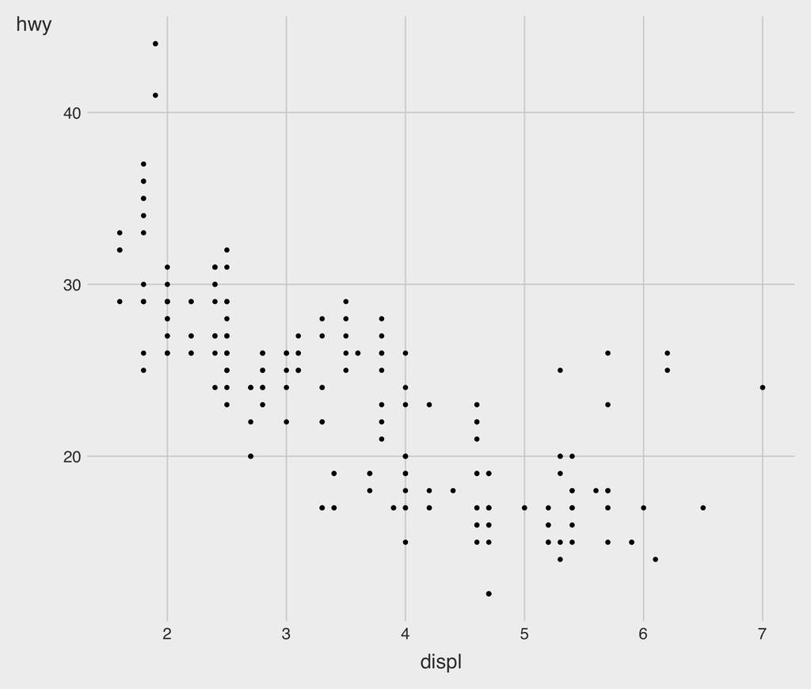

```r
ggplot(data = mpg) +
  geom_point(mapping =
               aes(x = displ,
                   y = hwy) )
```

- To plot `mpg`, run the above code to put `displ` on the `x`-axis and `hwy` on the `y`-axis.

## Data Visualization - First Steps

### Graphing Template

```r
ggplot(data = <DATA>) +
  <GEOM_FUNCTION>(mapping = aes(<MAPPINGS>))
```

- To make a ggplot plot, replace the bracketed sections in the code below with a `data.frame`, a `geom` function, or a collection of mappings such as `x = VAR_1` and `y = VAR_2`.

## R Basics

### R Variable and Data Types

- Question 1 in [Classwork 6](https://bcdanl.github.io/200/danl-cw/danl-200-cw-06.html)

## Aesthetic Mappings

## Aesthetic Mappings

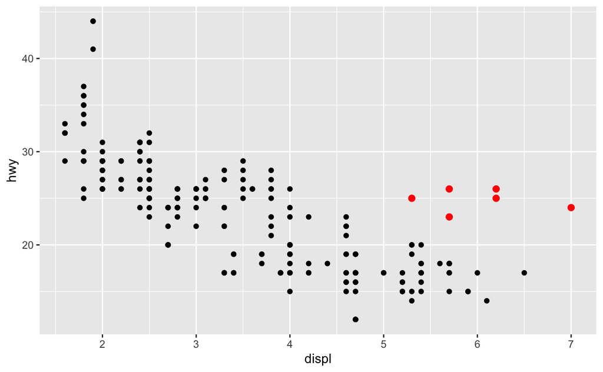

- In the plot above, one group of points (highlighted in red) seems to fall outside of the linear trend.
  - How can you explain these cars? Are those hybrids?

## Aesthetic Mappings

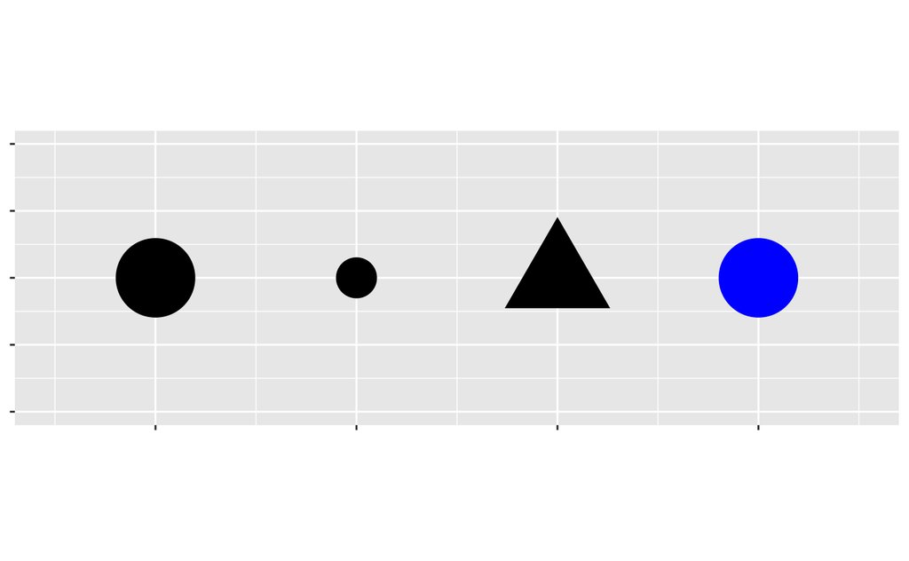

- An aesthetic is a visual property (e.g., `size`, `shape`, `color`) of the objects (e.g., `class`) in your plot.
- You can display a point in different ways by changing the values of its aesthetic properties.

## Aesthetic Mappings

### Adding a `color` to the plot

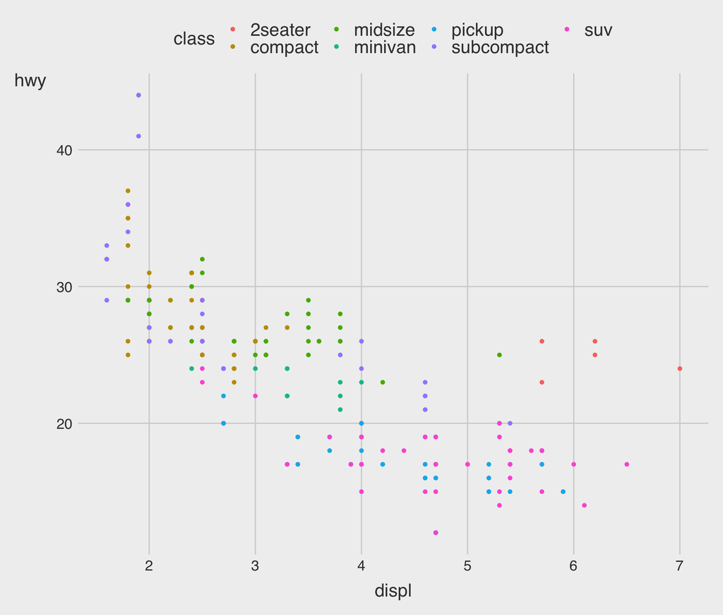

```r
ggplot(data = mpg) +
  geom_point(mapping =
               aes(x = displ,
                   y = hwy,
                   color = class) )
```

## Aesthetic Mappings

### Adding a `shape` to the plot

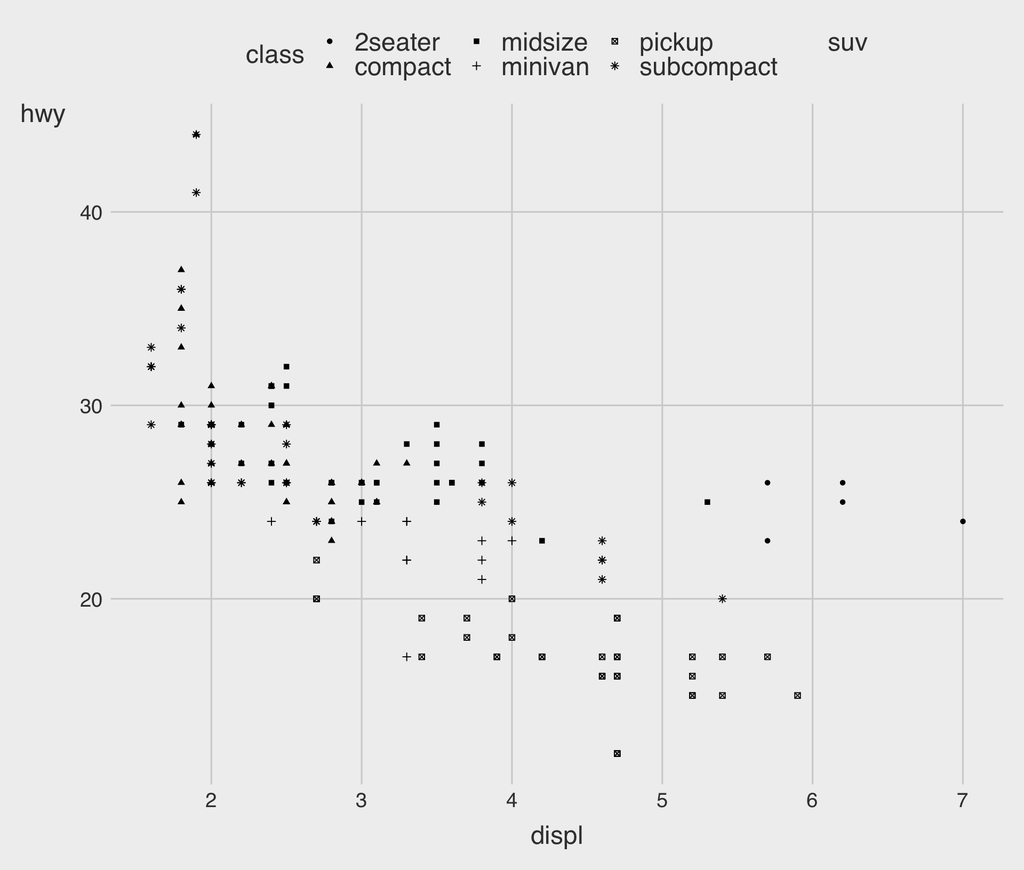

```r
ggplot(data = mpg) +
  geom_point(mapping =
               aes(x = displ,
                   y = hwy,
                   shape = class) )
```

## Aesthetic Mappings

### Adding a `size` to the plot

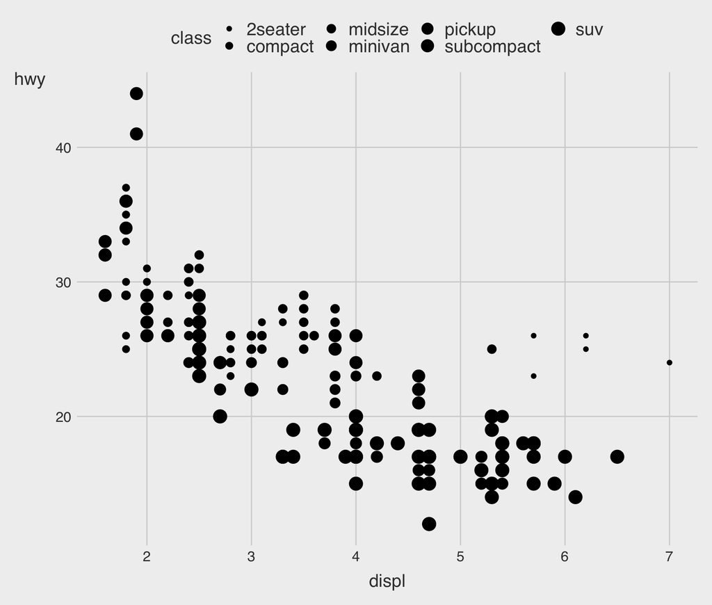

```r
ggplot(data = mpg) +
  geom_point(mapping =
               aes(x = displ,
                   y = hwy,
                   size = class) )
```

## Aesthetic Mappings

### Adding an `alpha` (transparency) to the plot

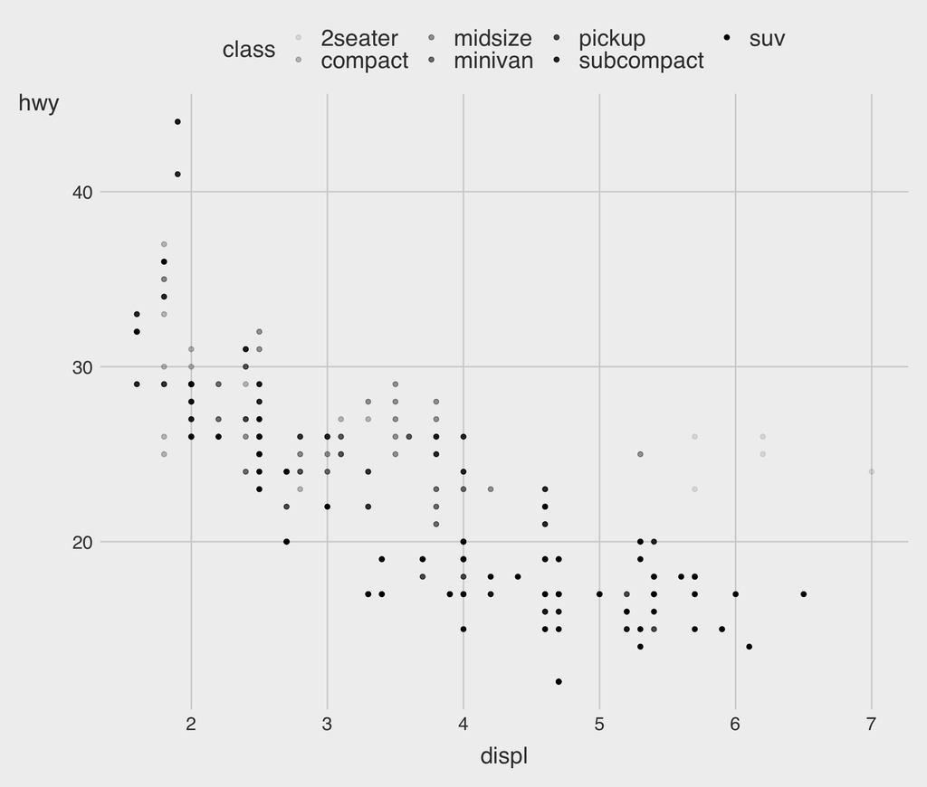

```r
ggplot(data = mpg) +
  geom_point(mapping =
               aes(x = displ,
                   y = hwy,
                   alpha = class) )
```

## Aesthetic Mappings

### Overplotting problem

- Many points overlap each other.
  - This problem is known as **overplotting**.
- When points overlap, it’s hard to know how many data points are at a particular location.
- Overplotting can obscure patterns and outliers, leading to potentially misleading conclusions.
- We can set a transparency level (`alpha`) between 0 (full transparency) and 1 (no transparency).

## Aesthetic Mappings

### Overplotting and `alpha`

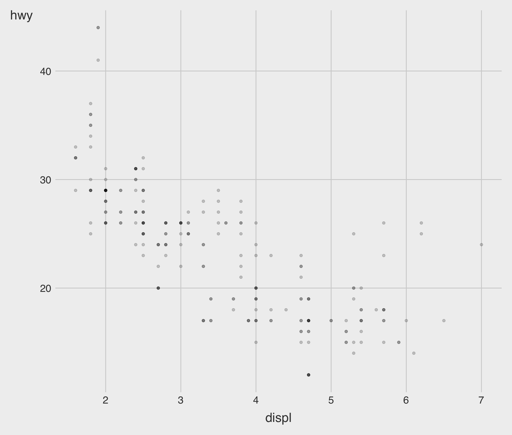

```r
ggplot(data = mpg) +
  geom_point(mapping =
               aes(x = displ,
                   y = hwy),
             alpha = .2)
```

## Aesthetic Mappings

### Specifying a `color` to the plot

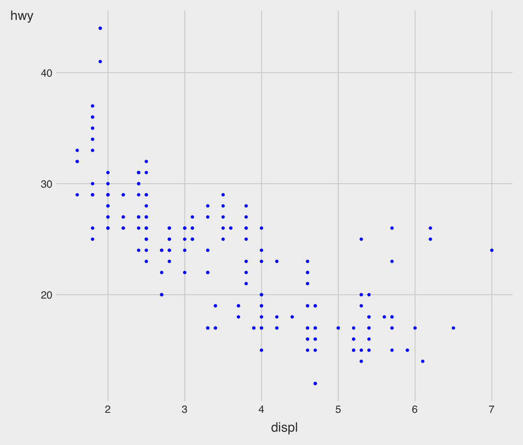

```r
ggplot(data = mpg) +
  geom_point(mapping =
               aes(x = displ,
                   y = hwy),
             color = "blue")
```

## Aesthetic Mappings

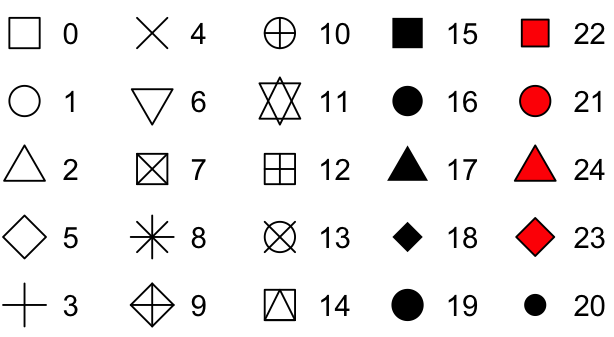

- To set an aesthetic manually, set the aesthetic by name as an argument of your `geom_` function; i.e. it goes outside of `aes()`.
  - You’ll need to pick a level that makes sense for that aesthetic:
    - The name of a `color` as a *character string*.
    - The `size` of a point in *mm*.
    - The `shape` of a point as a *number*, as shown below.

## Aesthetic Mappings

### Specifying a `color` to the plot?

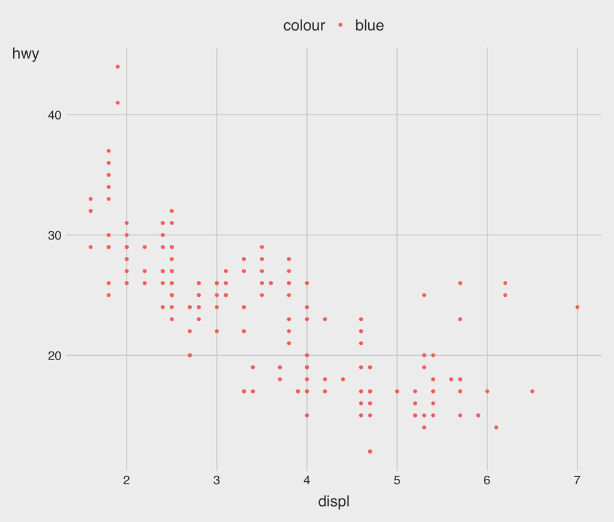

```r
ggplot(data = mpg) +
  geom_point( mapping =
                aes(x = displ,
                    y = hwy,
                    color = "blue") )
```

## Common problems in `ggplot()`

```r
ggplot(data = mpg)
 + geom_point( mapping =
                 aes(x = displ,
                     y = hwy) )
```

- One common problem when creating `ggplot2` graphics is to put the `+` in the wrong place.

## R Basics

### R Variable and Data Types

- Question 2 in [Classwork 6](https://bcdanl.github.io/200/danl-cw/danl-200-cw-06.html)

# Facets

## Facets

- One way to add a variable, particularly useful for categorical variables, is to use **facets** to split our plot into facets, subplots that each display one subset of the data.

## Facets

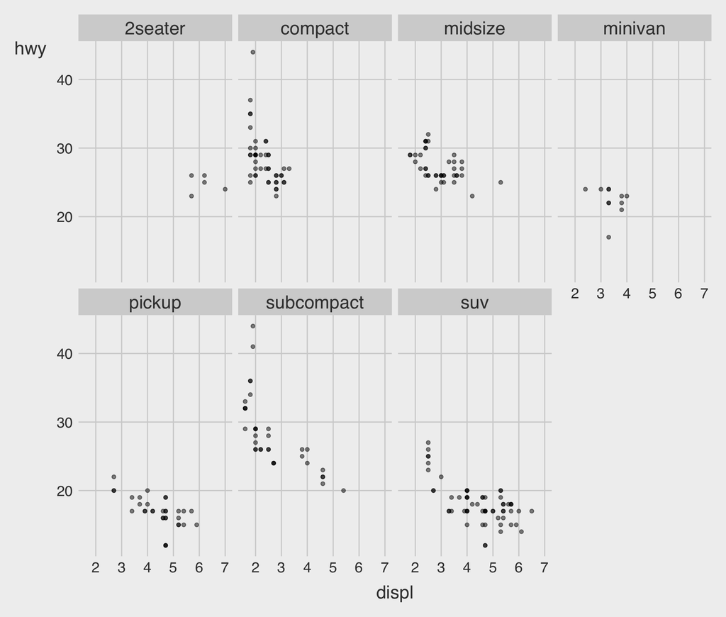

```r
ggplot(data = mpg) +
  geom_point(mapping =
               aes(x = displ,
                   y = hwy),
             alpha = .5) +
  facet_wrap( . ~ class, nrow = 2)
```

- To facet our plot by a *single variable*, use `facet_wrap()`.

## Facets

- To facet our plot on the combination of *two variables*, add `facet_grid( VAR_ROW ~ VAR_COL )` to our plot call.

## Facets

- The first argument of `facet_grid()` is also a formula.
  - This time the formula should contain two variable names separated by a `~`.

## Facets

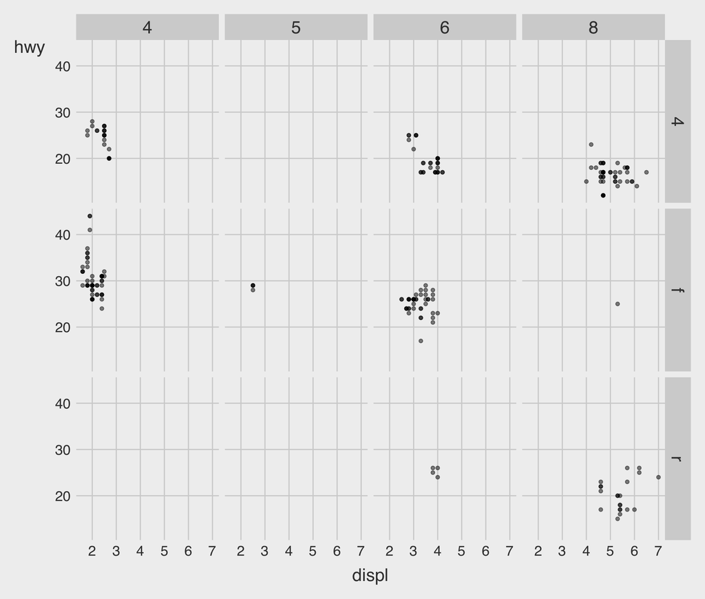

```r
ggplot(data = mpg) +
  geom_point(mapping =
               aes(x = displ,
                   y = hwy),
             alpha = .5) +
  facet_grid(drv ~ cyl)
```

## Facets

- Option `scales` in `facet_*()` is whether scales is
  - fixed (`"fixed"`, the default),
  - free in one dimension (`"free_x"`, `"free_y"`), or
  - free in two dimensions (`"free"`).

## Facets

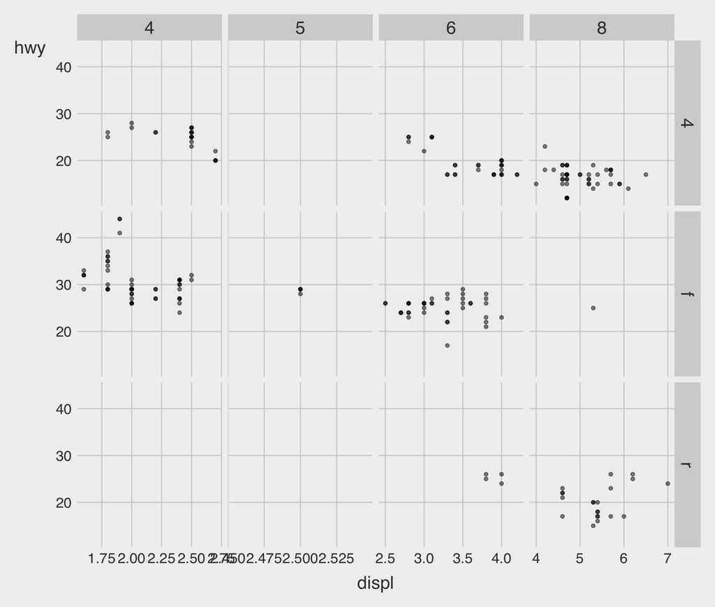

```r
ggplot(data = mpg) +
  geom_point(mapping =
               aes(x = displ,
                   y = hwy),
             alpha = .5) +
  facet_grid(drv ~ cyl,
             scales = "free_x")
```

## R Basics

### R Variable and Data Types

- Question 3 in [Classwork 6](https://bcdanl.github.io/200/danl-cw/danl-200-cw-06.html)